# Predictive Models Take Home Exam

### (b)

```r
logit.fit <- glm(Direction~.,data=Weekly[,c(2:7,9)] ,family=binomial)
summary(logit.fit)
```

```
##
## Call:
## glm(formula = Direction ~ ., family = binomial, data = Weekly[,
##     c(2:7, 9)])
##
## Deviance Residuals:
##     Min       1Q   Median       3Q      Max
## -1.6949  -1.2565   0.9913   1.0849   1.4579
##
## Coefficients:
##             Estimate Std. Error z value Pr(>|z|)
## (Intercept)  0.26686    0.08593   3.106   0.0019 **
## Lag1        -0.04127    0.02641  -1.563   0.1181
## Lag2         0.05844    0.02686   2.175   0.0296 *
## Lag3        -0.01606    0.02666  -0.602   0.5469
## Lag4        -0.02779    0.02646  -1.050   0.2937
## Lag5        -0.01447    0.02638  -0.549   0.5833
## Volume      -0.02274    0.03690  -0.616   0.5377
## ---
## Signif. codes:  0 '***' 0.001 '**' 0.01 '*' 0.05 '.' 0.1 ' ' 1
##
## (Dispersion parameter for binomial family taken to be 1)
##
##     Null deviance: 1496.2  on 1088  degrees of freedom
## Residual deviance: 1486.4  on 1082  degrees of freedom
## AIC: 1500.4
##
## Number of Fisher Scoring iterations: 4
```

It seems like only Lag2 has statistically significant value. No other predictors have any significant value.

### (c)

```r
logit.probs = predict(logit.fit, type = "response")
logit.pred = rep("Down", length(logit.probs))
logit.pred[logit.probs > 0.5] = "Up"
contrasts(Weekly$Direction)
```

```
##      Up
## Down  0
## Up    1
```

```r
table(logit.pred, Weekly$Direction)
```

```
##
## logit.pred Down  Up
##       Down   54  48
##       Up    430 557
```

```r
(54+557) / (54+430+48+557) # Accuracy
```

```
## [1] 0.5610652
```

```r
48 / (54+48) # FPR
```

```
## [1] 0.4705882
```

This model has 56.11% accuracy.  
Missclassification rate is 43.89%.  
False Positive rate is 47%.

### (d)

```r
train = Weekly$Year<2009
Weekly_train = Weekly[train,]
Weekly_test = Weekly[-train,]

logit.fit2 = glm(Direction~Lag2, data = Weekly_train, family = binomial)
summary(logit.fit2)
```

```
##
## Call:
## glm(formula = Direction ~ Lag2, family = binomial, data = Weekly_train)
##
## Deviance Residuals:
##    Min      1Q  Median      3Q     Max
## -1.536  -1.264   1.021   1.091   1.368
##
## Coefficients:
##             Estimate Std. Error z value Pr(>|z|)
## (Intercept)  0.20326    0.06428   3.162  0.00157 **
## Lag2         0.05810    0.02870   2.024  0.04298 *
## ---
## Signif. codes:  0 '***' 0.001 '**' 0.01 '*' 0.05 '.' 0.1 ' ' 1
##
## (Dispersion parameter for binomial family taken to be 1)
##
##     Null deviance: 1354.7  on 984  degrees of freedom
## Residual deviance: 1350.5  on 983  degrees of freedom
## AIC: 1354.5
##
## Number of Fisher Scoring iterations: 4
```

```r
logit.probs2 = predict(logit.fit2, newdata=Weekly_test, type = "response")
logit.pred2 = rep("Down", length(logit.probs2))
logit.pred2[logit.probs2 > 0.5] = "Up"
contrasts(Weekly_train$Direction)
```

```
##      Up
## Down  0
## Up    1
```

```r
table(logit.pred2, Weekly_test$Direction)
```

```
##
## logit.pred2 Down  Up
##        Down   32  25
##        Up    451 580
```

```r
mean(logit.pred2 == Weekly_test$Direction)
```

```
## [1] 0.5625
```

```r
25/(32+25)
```

```
## [1] 0.4385965
```

Accuracy is 56.25%, better than previous model.  
False Positive rate is 43.86%, lower than previous model.

### (g)

```r
library(class)
set.seed(99)
train_xmat <- as.matrix(Weekly_train$Lag2)
test_xmat <- as.matrix(Weekly_test$Lag2)
knn.fit <- knn(train_xmat, test_xmat, Weekly_train$Direction, k=1)
table(knn.fit, Weekly_test$Direction)
```

```
##
## knn.fit Down  Up
##    Down  437  46
##    Up     46 559
```

```r
mean(knn.fit == Weekly_test$Direction)
```

```
## [1] 0.9154412
```

```r
46/(437+46)
```

```
## [1] 0.0952381
```

Accuracy for KNN is 91.54%, much higher than previous models.  
False Positive rate is only 9.5%, much lower than previous models.

### (h)

For this problem, KNN produced the best result. Because KNN model has the highest accuracy and lowest false positive rate.

### (i)

#### LOgitic Regression with Lag1, Lag2 and Lag1*Lag2

```r
logit.fit3 <- glm(Direction~Lag1*Lag2, data = Weekly_train, family = binomial)
summary(logit.fit3)
```

```
##
## Call:
## glm(formula = Direction ~ Lag1 * Lag2, family = binomial, data = Weekly_train)
##
## Deviance Residuals:
##    Min      1Q  Median      3Q     Max
## -1.573  -1.259   1.003   1.086   1.596
##
## Coefficients:
##              Estimate Std. Error z value Pr(>|z|)
## (Intercept)  0.211419   0.064589   3.273  0.00106 **
## Lag1        -0.051505   0.030727  -1.676  0.09370 .
## Lag2         0.053471   0.029193   1.832  0.06700 .
## Lag1:Lag2    0.001921   0.007460   0.257  0.79680
## ---
## Signif. codes:  0 '***' 0.001 '**' 0.01 '*' 0.05 '.' 0.1 ' ' 1
##
## (Dispersion parameter for binomial family taken to be 1)
##
##     Null deviance: 1354.7  on 984  degrees of freedom
## Residual deviance: 1346.9  on 981  degrees of freedom
## AIC: 1354.9
##
## Number of Fisher Scoring iterations: 4
```

```r
logit.probs3 = predict(logit.fit3, newdata=Weekly_test, type = "response")
logit.pred3 = rep("Down", length(logit.probs3))
logit.pred3[logit.probs3 > 0.5] = "Up"
table(logit.pred3, Weekly_test$Direction)
```

```
##
## logit.pred3 Down  Up
##        Down   49  55
##        Up    434 550
```

```r
mean(logit.pred3 == Weekly_test$Direction)
```

```
## [1] 0.5505515
```

#### LOgitic Regression with only Lag1

```r
logit.fit4 <- glm(Direction~Lag1, data = Weekly_train, family = binomial)
summary(logit.fit4)
```

```
##
## Call:
## glm(formula = Direction ~ Lag1, family = binomial, data = Weekly_train)
##
## Deviance Residuals:
##    Min      1Q  Median      3Q     Max
## -1.519  -1.253   1.028   1.094   1.281
##
## Coefficients:
##             Estimate Std. Error z value Pr(>|z|)
## (Intercept)  0.21829    0.06438   3.391 0.000697 ***
## Lag1        -0.05908    0.02892  -2.043 0.041059 *
## ---
## Signif. codes:  0 '***' 0.001 '**' 0.01 '*' 0.05 '.' 0.1 ' ' 1
##
## (Dispersion parameter for binomial family taken to be 1)
##
##     Null deviance: 1354.7  on 984  degrees of freedom
## Residual deviance: 1350.4  on 983  degrees of freedom
## AIC: 1354.4
##
## Number of Fisher Scoring iterations: 4
```

```r
logit.probs4 = predict(logit.fit4, newdata=Weekly_test, type = "response")
logit.pred4 = rep("Down", length(logit.probs3))
logit.pred4[logit.probs4 > 0.5] = "Up"
table(logit.pred4, Weekly_test$Direction)
```

```
##
## logit.pred4 Down  Up
##        Down   28  29
##        Up    455 576
```

```r
mean(logit.pred4 == Weekly_test$Direction)
```

```
## [1] 0.5551471
```

#### KNN with different k

```r
knn.fit2 <- knn(train_xmat, test_xmat, Weekly_train$Direction, k=10)
table(knn.fit2, Weekly_test$Direction)
```

```
##
## knn.fit2 Down  Up
##     Down  223 155
##     Up    260 450
```

```r
mean(knn.fit2 == Weekly_test$Direction)
```

```
## [1] 0.6185662
```

```r
knn.fit3 <- knn(train_xmat, test_xmat, Weekly_train$Direction, k=20)
table(knn.fit3, Weekly_test$Direction)
```

```
##
## knn.fit3 Down  Up
##     Down  206 147
##     Up    277 458
```

```r
mean(knn.fit3 == Weekly_test$Direction)
```

```
## [1] 0.6102941
```

## Chapter 8 # 8

### (a)

```r
rm(list=ls())

set.seed(99)
train <- createDataPartition(y = Carseats$Sales, p=0.8,list = F)
Carseats_train = Carseats[train,]
Carseats_test = Carseats[-train,]
```

### (b)

```r
library(tree)
tree.fit <- tree(Sales~., data = Carseats_train)
summary(tree.fit)
```

```
##
## Regression tree:
## tree(formula = Sales ~ ., data = Carseats_train)
## Variables actually used in tree construction:
## [1] "ShelveLoc" "Price"     "Age"       "Income"    "CompPrice"
## Number of terminal nodes:  18
## Residual mean deviance:  2.622 = 794.5 / 303
## Distribution of residuals:
##     Min.  1st Qu.   Median     Mean  3rd Qu.     Max.
## -4.32600 -1.04800  0.04824  0.00000  1.09900  4.12200
```

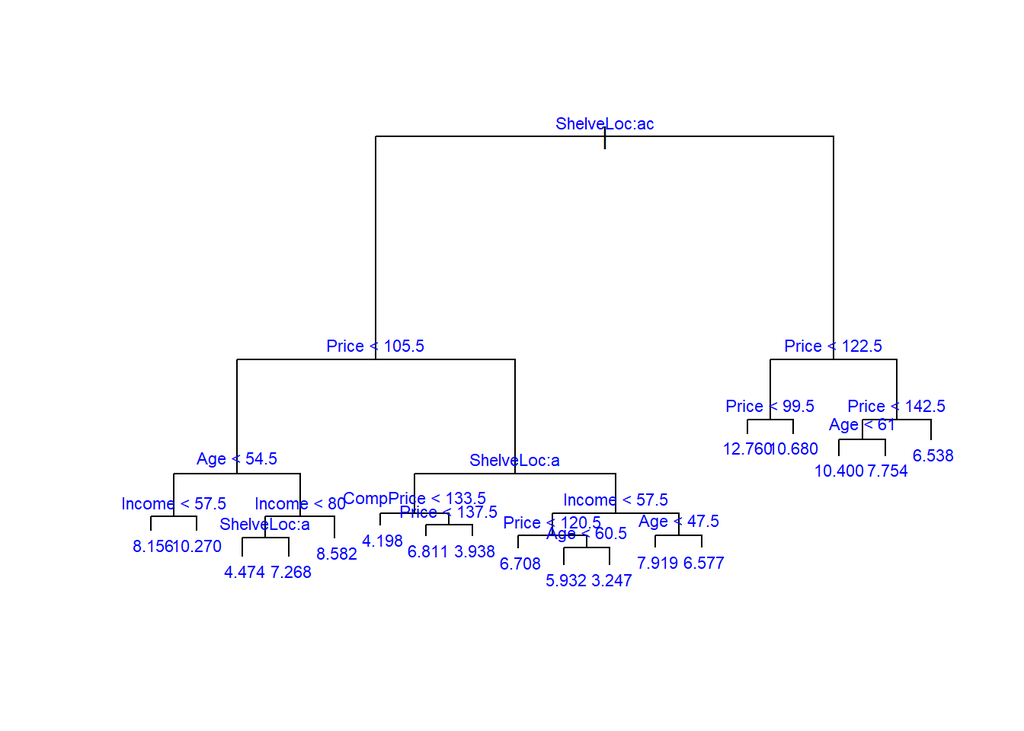

```r
plot(tree.fit)
text(tree.fit,col="blue",cex=.7)
```

```r
tree.pred = predict(tree.fit, Carseats_test)
mean((Carseats_test$Sales - tree.pred)^2)
```

```
## [1] 4.983931
```

This tree model’s test MSE is 4.983931.

### (c)

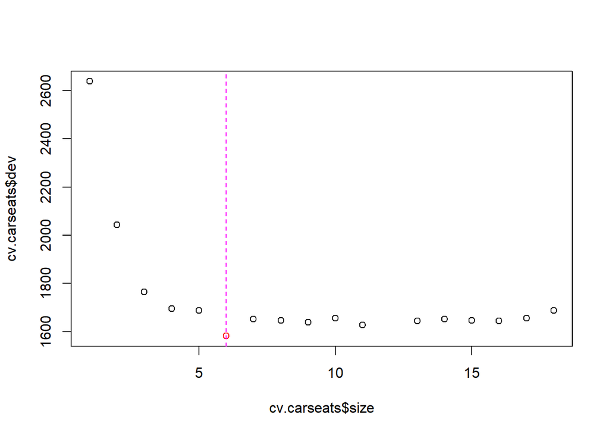

```r
set.seed(99)
cv.carseats <- cv.tree(tree.fit, FUN=prune.tree)
best_size_index= which(cv.carseats$dev==min(cv.carseats$dev))
best_size = cv.carseats$size[best_size_index]
plot(cv.carseats$size, cv.carseats$dev)
points(cv.carseats$size[best_size_index],cv.carseats$dev[best_size_index],col="red")
abline(v=cv.carseats$size[best_size_index],col='magenta',lty=2)
```

```r
best_size
```

```
## [1] 6
```

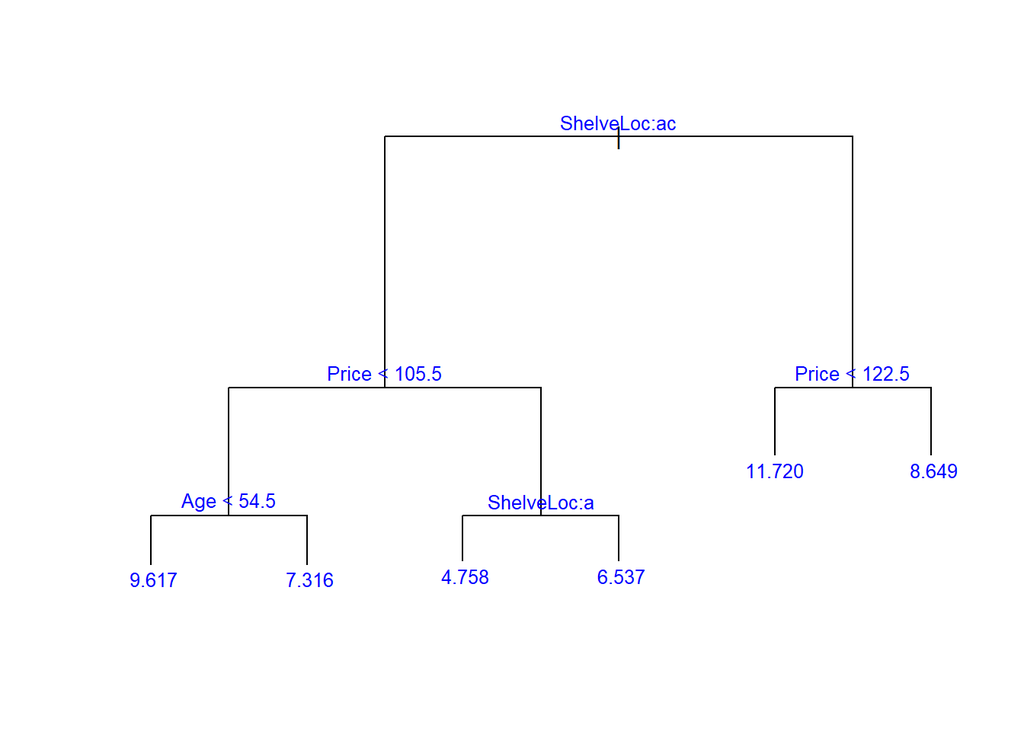

```r
prune.carseats = prune.tree(tree.fit, best = 6)
plot(prune.carseats)
text(prune.carseats,col="blue",cex=.8)
```

```r
prune.pred <- predict(prune.carseats,newdata=Carseats_test)
mean((Carseats_test$Sales - prune.pred)^2)
```

```
## [1] 4.748888
```

After cross-validation, model choose size 6 as its optimal level of tree complexity. After pruning, test MSE is 4.7488. It makes improvement from tree model.

### (d)

```r
library(randomForest)
set.seed(99)

bag.fit <- randomForest(Sales~., data=Carseats_train, mtry=10,ntree=1000,importance=T)
bag.pred = predict(bag.fit,Carseats_test)
mean((Carseats_test$Sales - bag.pred)^2)
```

```
## [1] 2.153094
```

```r
importance(bag.fit)
```

```
##                %IncMSE IncNodePurity
## CompPrice    48.933149     292.19096
## Income       19.471497     143.49670
## Advertising  29.149664     173.14999
## Population   -1.626541      76.16325
## Price       105.233084     794.37063
## ShelveLoc   108.806186     731.10275
## Age          35.055610     249.54501
## Education     4.420372      60.79298
## Urban        -2.162752      10.55304
## US            4.270568      12.89869
```

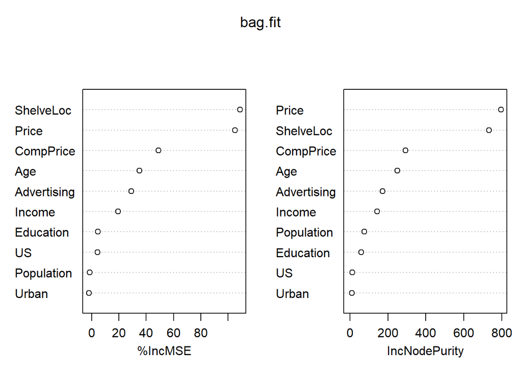

```r
varImpPlot(bag.fit)
```

Test MSE is 2.153094. It seems that bagging model is much better than tree model.  
We can see that ShelveLoc and Price are top 2 most important variables.

### (e)

```r
set.seed(99)

rf.fit <- randomForest(Sales~., data=Carseats_train, mtry=3,ntree=1000,importance=T)
rf.pred = predict(rf.fit,Carseats_test)
mean((Carseats_test$Sales - rf.pred)^2)
```

```
## [1] 2.561612
```

```r
importance(rf.fit)
```

```
##                %IncMSE IncNodePurity
## CompPrice   23.1218660     239.14128
## Income       3.7171777     185.19666
## Advertising 24.4450671     218.58955
## Population  -1.1802218     150.20769
## Price       66.5756423     645.86730
## ShelveLoc   71.0440664     572.20779
## Age         25.2286954     283.32034
## Education    0.9468814     108.35866
## Urban       -2.3191687      19.79767
## US          10.1201400      47.12222
```

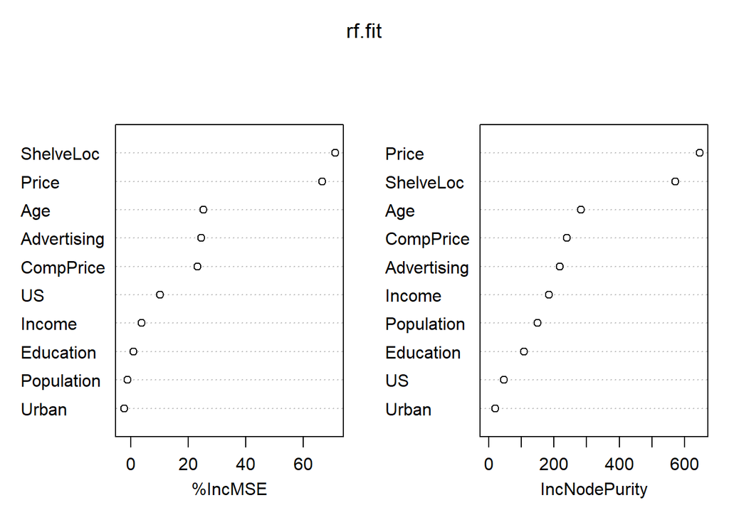

```r
varImpPlot(rf.fit)
```

Test MSE is 2.561612, slightly higher than bagging model.  
ShelveLoc and Price are still top 2 most important variables.

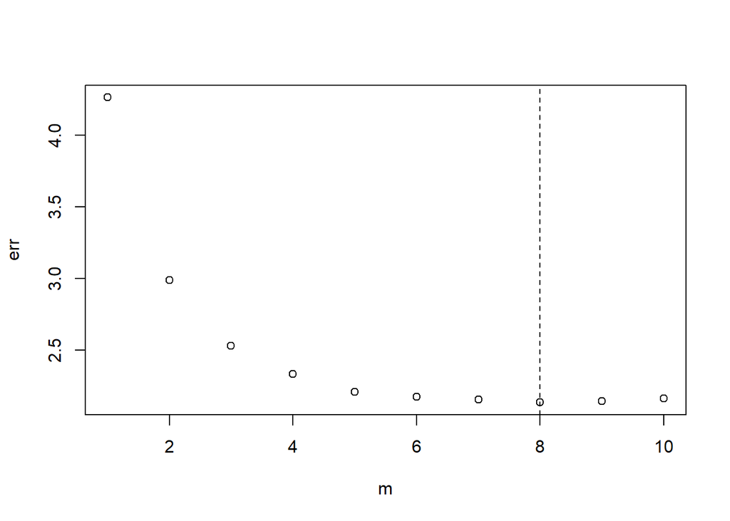

```r
set.seed(99)

err = c()
for (i in c(1:10)){
  rf.fit <- randomForest(Sales~., data=Carseats_train, mtry=i,ntree=1000,importance=T)
  rf.pred = predict(rf.fit,Carseats_test)
  err[i] = mean((Carseats_test$Sales - rf.pred)^2)
}
m=c(1:10)
plot(m,err)
abline(v=m[which(err==min(err))],lty=2)
```

```r
err[which(err==min(err))]
```

```
## [1] 2.134007
```

If m increase, it means we use more predictors per tree, the model will be more complex. In this case, using m=8 can obtain the lowest test MSE: 2.134007. It is lower than bagging model’s test MSE.

## Chapter 8 # 11

### (a)

```r
rm(list=ls())

train<-c(1:1000)
Caravan$Purchase = ifelse(Caravan$Purchase == "Yes", 1, 0)
Caravan_train = Caravan[train, ]
Caravan_test = Caravan[-train, ]
```

### (b)

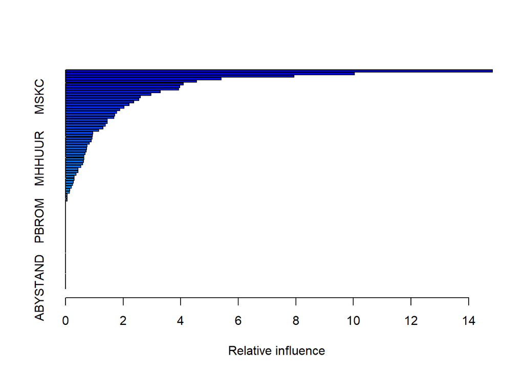

```
##               var     rel.inf
## PPERSAUT PPERSAUT 14.82584334
## MKOOPKLA MKOOPKLA 10.04065671
## MOPLHOOG MOPLHOOG  7.93976564
## MBERMIDD MBERMIDD  5.39932190
## PBRAND     PBRAND  4.55273454
## MINK3045 MINK3045  4.09483320
## MGODGE     MGODGE  3.96736086
## ABRAND     ABRAND  3.92866656
## MAUT2       MAUT2  3.29395164
## MOSTYPE   MOSTYPE  2.96711808
## MSKC         MSKC  2.59717110
## PWAPART   PWAPART  2.55029945
## MGODPR     MGODPR  2.37376800
## MSKA         MSKA  2.20834602
## MINKGEM   MINKGEM  2.03344587
## MBERARBG MBERARBG  1.87997905
## MAUT1       MAUT1  1.77590859
## MSKB1       MSKB1  1.71098971
## MBERHOOG MBERHOOG  1.68513030
## PBYSTAND PBYSTAND  1.45602693
## MFWEKIND MFWEKIND  1.44576283
## MGODOV     MGODOV  1.38585955
## MRELGE     MRELGE  1.29537848
## MHKOOP     MHKOOP  1.15737592
## APERSAUT APERSAUT  0.94557292
## MINKM30   MINKM30  0.93127474
## MFGEKIND MFGEKIND  0.92717172
## MINK7512 MINK7512  0.89571099
## MSKD         MSKD  0.82696647
## MBERARBO MBERARBO  0.74872778
## MOPLMIDD MOPLMIDD  0.73825308
## MAUT0       MAUT0  0.71810840
## MZFONDS   MZFONDS  0.67338350
## MINK4575 MINK4575  0.64147909
## MHHUUR     MHHUUR  0.63181959
## MGODRK     MGODRK  0.61998842
## MBERBOER MBERBOER  0.59946070
## MRELOV     MRELOV  0.52762345
## MINK123M MINK123M  0.43503455
```

[output cut: 31 more lines]

```
## AMOTSCO   AMOTSCO  0.00000000
## AVRAAUT   AVRAAUT  0.00000000
## AAANHANG AAANHANG  0.00000000
## ATRACTOR ATRACTOR  0.00000000
## AWERKT     AWERKT  0.00000000
## ABROM       ABROM  0.00000000
## ALEVEN     ALEVEN  0.00000000
## APERSONG APERSONG  0.00000000
## AGEZONG   AGEZONG  0.00000000
## AWAOREG   AWAOREG  0.00000000
## AZEILPL   AZEILPL  0.00000000
## APLEZIER APLEZIER  0.00000000
## AFIETS     AFIETS  0.00000000
## AINBOED   AINBOED  0.00000000
## ABYSTAND ABYSTAND  0.00000000
```

```r
library(gbm)
set.seed(99)
boost.fit <- gbm(Purchase~., data = Caravan_train, n.trees = 1000, shrinkage = 0.01,distribution = "bernoulli")
summary(boost.fit)
```

It seems like PPERSAUT, MKOOPKLA and MOPLHOOG are top 3 most important predictors for this boosting model.

### (c)

#### Boosting

```r
boost.prob = predict(boost.fit, Caravan_test, n.trees = 1000, type = "response")
boost.pred = ifelse(boost.prob > 0.2, 1, 0)
table(Caravan_test$Purchase, boost.pred)
```

```
##    boost.pred
##        0    1
##   0 4410  123
##   1  256   33
```

```r
33/(123+33)
```

```
## [1] 0.2115385
```

```r
accuracy_boost = mean((Caravan_test$Purchase==boost.pred))
accuracy_boost
```

```
## [1] 0.9214019
```

```r
set.seed(99)

train_matx = as.matrix(subset(Caravan_train, select = -Purchase))
test_matx = as.matrix(subset(Caravan_test, select = -Purchase))

accuracy_knn=c()
for (i in c(1:10)) {
  knn.pred <- knn(train_matx, test_matx,Caravan_train$Purchase, k=i)
  accuracy_knn[i] = mean(Caravan_test$Purchase==knn.pred)
}
best_k = which(accuracy_knn==max(accuracy_knn))
best_k
```

```
## [1]  9 10
```

```r
knn.pred10 <- knn(train_matx, test_matx,Caravan_train$Purchase, k=10)
table(Caravan_test$Purchase, knn.pred10)
```

```
##    knn.pred10
##        0    1
##   0 4528    5
##   1  289    0
```

```r
accuracy_knn[10]
```

```
## [1] 0.9392368
```

As we can see, when k reach 9 and higher, accuracy tends to stablize. We should choose k=10, because it is a much less complex model. Using k=10 KNN, we predict 5 people will purchase but in fact there is no purchase. The reason might be that in KNN, we cannot change the threshold just like logistic regression or boosting.  
This KNN model has 93.92% accuracy

#### Logistic Regression

```r
logit.fit <- glm(Purchase~., data = Caravan_train, family = binomial)
logit.prob <- predict(logit.fit, newdata=Caravan_test, type="response")
logit.pred = ifelse(logit.prob > 0.2, 1, 0)
table(Caravan_test$Purchase, logit.pred)
```

```
##    logit.pred
##        0    1
##   0 4183  350
##   1  231   58
```

```r
58/(350+58)
```

```
## [1] 0.1421569
```

```r
accuracy_logit = mean((Caravan_train$Purchase==logit.pred))
accuracy_logit
```

```
## [1] 0.8664455
```

## Problem 1: Beauty Pays!

### 1.

```r
rm(list=ls())
library(caret)

df_beauty <- read.csv("C:/Joey/MSBA Summer/Intro to Predictive Model/dataset/BeautyData.csv")

set.seed(9)

train <- createDataPartition(y = df_beauty$CourseEvals, p=0.8,list = F)
beauty_train <- df_beauty[train,]
beauty_test <- df_beauty[-train,]

beauty.fit <- lm(CourseEvals~BeautyScore, data = beauty_train)
summary(beauty.fit)
```

```
##
## Call:
## lm(formula = CourseEvals ~ BeautyScore, data = beauty_train)
##
## Residuals:
##     Min      1Q  Median      3Q     Max
## -1.5693 -0.3434  0.0085  0.3305  1.2588
##
## Coefficients:
##             Estimate Std. Error t value Pr(>|t|)
## (Intercept)  3.70544    0.02512  147.52   <2e-16 ***
## BeautyScore  0.29672    0.03211    9.24   <2e-16 ***
## ---
## Signif. codes:  0 '***' 0.001 '**' 0.01 '*' 0.05 '.' 0.1 ' ' 1
##
## Residual standard error: 0.4818 on 369 degrees of freedom
## Multiple R-squared:  0.1879, Adjusted R-squared:  0.1857
## F-statistic: 85.38 on 1 and 369 DF,  p-value: < 2.2e-16
```

```r
beauty.pred <- predict(beauty.fit, newdata = beauty_test)
beauty_mse <- mean((beauty_test$CourseEvals - beauty.pred)^2)
beauty_mse
```

```
## [1] 0.2303482
```

First, we can consider using a simple regression to see the effect of beauty into course ratings. As we can see, this linear model says that beauty predictors has a statistically siginificant value. The coefficient is positive, so we can say if the teacher is beautiful, his or her course ratings will be higher.  
This simple regression model has 0.2303 test MSE.  
Now, we should consider other determinants that will affect course ratings.

```r
all.fit <- lm(CourseEvals~., data = beauty_train)
summary(all.fit)
```

```
##
## Call:
## lm(formula = CourseEvals ~ ., data = beauty_train)
##
## Residuals:
##      Min       1Q   Median       3Q      Max
## -1.33351 -0.29781  0.02221  0.27301  1.05126
##
## Coefficients:
##             Estimate Std. Error t value Pr(>|t|)
## (Intercept)  4.03654    0.05845  69.058  < 2e-16 ***
## BeautyScore  0.32449    0.02858  11.354  < 2e-16 ***
## female      -0.33915    0.04512  -7.517 4.39e-13 ***
## lower       -0.35022    0.04829  -7.252 2.48e-12 ***
## nonenglish  -0.31655    0.09289  -3.408 0.000728 ***
## tenuretrack -0.06220    0.05532  -1.124 0.261564
## ---
## Signif. codes:  0 '***' 0.001 '**' 0.01 '*' 0.05 '.' 0.1 ' ' 1
##
## Residual standard error: 0.4249 on 365 degrees of freedom
## Multiple R-squared:  0.3751, Adjusted R-squared:  0.3665
## F-statistic: 43.82 on 5 and 365 DF,  p-value: < 2.2e-16
```

```r
all.pred <- predict(all.fit, newdata = beauty_test)
all_mse <- mean((beauty_test$CourseEvals - all.pred)^2)
all_mse
```

```
## [1] 0.1943089
```

As we can see, every predictors have a statistically significant value, except for tenure track. This model tells us, if the teacher is pretty, his or her course rating will be high. If the teacher is a female, course rating will be low. If the course is lower division class, the rating will be low. If the teacher’s native language is not English, the rating will be low.  
This model has 0.1943 test MSE, meaning it is better than the previous simple regression model.

### 2.

Regression model can capture predictor’s effect on dependent variable. We can see if the predictors have correlation with dependent variable, and we can know how much increase in predictors will lead to how much change in dependent variable. But it is hard to know if there is any causality.  
Furthermore, it is impossible to know whether this outcome represents productivity or discrimination, because there is no way we can seperate these effect in linear regression. We wouldn’t know beautiful teachers make students learn more and give higher ratings, or students want to give higher rating just because teachers are beautiful. Only thing we know is that if teachers are more beautiful, they tends to get higher ratings.

## Problem 2: Housing Price Structure

### 1

```r
rm(list=ls())

df_city <- read.csv("C:/Joey/MSBA Summer/Intro to Predictive Model/dataset/MidCity.csv")
df_city$Nbhd<-as.factor(df_city$Nbhd)
city.fit = lm(Price~.-Home, data = df_city)
summary(city.fit)
```

```
##
## Call:
## lm(formula = Price ~ . - Home, data = df_city)
##
## Residuals:
##      Min       1Q   Median       3Q      Max
## -27337.3  -6549.5    -41.7   5803.4  27359.3
##
## Coefficients:
##              Estimate Std. Error t value Pr(>|t|)
## (Intercept)  2159.498   8877.810   0.243  0.80823
## Nbhd2       -1560.579   2396.765  -0.651  0.51621
## Nbhd3       20681.037   3148.954   6.568 1.38e-09 ***
## Offers      -8267.488   1084.777  -7.621 6.47e-12 ***
## SqFt           52.994      5.734   9.242 1.10e-15 ***
## BrickYes    17297.350   1981.616   8.729 1.78e-14 ***
## Bedrooms     4246.794   1597.911   2.658  0.00894 **
## Bathrooms    7883.278   2117.035   3.724  0.00030 ***
## ---
## Signif. codes:  0 '***' 0.001 '**' 0.01 '*' 0.05 '.' 0.1 ' ' 1
##
## Residual standard error: 10020 on 120 degrees of freedom
## Multiple R-squared:  0.8686, Adjusted R-squared:  0.861
## F-statistic: 113.3 on 7 and 120 DF,  p-value: < 2.2e-16
```

According to the linear model result, BrickYes has statistically significant positive coefficient. It means that when everything else being equal, brick houses tend to have a premium of 17297.35.

### 2

According to the linear model result, Nbhd3 has statistically significant positive coefficient. It means that when other predictors being equal, houses in neighborhood 3 tend to have 20681.037 more price than neighborhood 1.

### 3

Brick houses in neighborhood 3 tend to have 37978.387 more price than non-brick houses in neighborhood 1.

### 4

```r
df_city$Nbhd<-as.integer(df_city$Nbhd)
df_city$Nbhd<-ifelse(df_city$Nbhd==3,"newer","older")
df_city$Price<-scale(df_city$Price)
set.seed(99)
train <- createDataPartition(y=df_city$Price, p=0.8, list=F)
city_train <- df_city[train,]
city_test <- df_city[-train,]

city.fit2 = lm(Price~.-Home, data = city_train)
summary(city.fit2)
```

```
##
## Call:
## lm(formula = Price ~ . - Home, data = city_train)
##
## Residuals:
##      Min       1Q   Median       3Q      Max
## -1.00297 -0.24918  0.00125  0.20478  0.96072
##
## Coefficients:
##              Estimate Std. Error t value Pr(>|t|)
## (Intercept) -3.904824   0.420969  -9.276 4.91e-15 ***
## Nbhdolder   -0.785833   0.106128  -7.405 4.83e-11 ***
## Offers      -0.322434   0.042571  -7.574 2.13e-11 ***
## SqFt         0.001875   0.000237   7.910 4.16e-12 ***
## BrickYes     0.603899   0.081383   7.420 4.48e-11 ***
## Bedrooms     0.167094   0.066272   2.521 0.013320 *
## Bathrooms    0.336323   0.086048   3.909 0.000172 ***
## ---
## Signif. codes:  0 '***' 0.001 '**' 0.01 '*' 0.05 '.' 0.1 ' ' 1
##
## Residual standard error: 0.3765 on 97 degrees of freedom
## Multiple R-squared:  0.8638, Adjusted R-squared:  0.8553
## F-statistic: 102.5 on 6 and 97 DF,  p-value: < 2.2e-16
```

```r
city.pred <- predict(city.fit2, newdata = city_test)
city.mse <- mean((city_test$Price - city.pred)^2)
city.mse
```

```
## [1] 0.130332
```

After changing neighborhood 1 and 2 to older, we can see that older neighborhood tends to decrease price value. After scaling price value, we can see that this linear regression model has 0.130332 test MSE.

## Problem 3: What caues what??

### 1

Becuase we don’t know which variable is the cause. Government tends to put more cops on higher crime areas. So, if we apply linear regression using Crime and Police, we cannot explain what happens. Maybe more cops leads to more crime, or this area has more crime so the government sends more cops in this area.

### 2

They add a new variable called TerrorismAlert. This variable has nothing to do with street crime, but it has strong relation with police number. So, in high alert day police number will increase becuse of the terrorism alert, not because of the street crime. Now, we can observe if street crime decrease due to the increase of the police. This concept is similar to Instrumental Variable. We can find a variable related to predictors but not correlated to the dependent variable. As a result, we can use this variable to observe the changing in dependent variable, then isolating the changing of the predictor.  
So, in Table 2, we can see that when alert is high, it makes the number of police increases, then crime significantly decreases.

### 3

They made a hypothesis that maybe number of the tourists decreases because of the high terrorism alert, then causes low victim in street crime. So, when they add METRO ridership into the regression model, they can see how terrorism alert affects crime rates holding number of the tourists or potential victims fixed. By doing this, they can be sure that crime rates go down not because terror alert makes the number of the potential victims decrease.

### 4

They added initeraction between terrorism alert and districts. It is because when terrorism alert is high, police will flood into district that is most likely to be attacked, such as White House. Holding other districts fixed, we can examine how terrorism alert affects in district 1.

## Problem 4: BART

#### Random Forest

```r
rm(list=ls())
library(caret)
library(BART)
library(randomForest)
library(gbm)

df_ca <- read.csv("C:/Joey/MSBA Summer/Intro to Predictive Model/dataset/CAhousing.csv")
df_ca$medianHouseValue <- log(df_ca$medianHouseValue)

set.seed(99)

train <- createDataPartition(y=df_ca$medianHouseValue,p=0.8,list=F)
ca_train <- df_ca[train,]
ca_test <- df_ca[-train,]

p=ncol(ca_train)-1
mtryv = c(sqrt(p),p)
ntreev = c(100,500)
parmrf = expand.grid(mtryv,ntreev)
colnames(parmrf)=c('mtry','ntree')
nset = nrow(parmrf)
olrf = rep(0,nset)
ilrf = rep(0,nset)
rffitv = vector('list',nset)
for(i in 1:nset) {
  cat('doing rf ',i,' out of ',nset,'\n')
  temprf = randomForest(medianHouseValue~.,data=ca_train,mtry=parmrf[i,1],ntree=parmrf[i,2])
  ifit = predict(temprf)
  ofit=predict(temprf,newdata=ca_test)
  olrf[i] = sum((ca_test$medianHouseValue-ofit)^2)
  ilrf[i] = sum((ca_train$medianHouseValue-ifit)^2)
  rffitv[[i]]=temprf
}
```

```
## doing rf  1  out of  4
## doing rf  2  out of  4
## doing rf  3  out of  4
## doing rf  4  out of  4
```

```r
ilrf = round(sqrt(ilrf/nrow(ca_train)),3); olrf = round(sqrt(olrf/nrow(ca_test)),3)

print(cbind(parmrf,olrf,ilrf))
```

```
##       mtry ntree  olrf  ilrf
## 1 2.828427   100 0.232 0.238
## 2 8.000000   100 0.228 0.230
## 3 2.828427   500 0.231 0.234
## 4 8.000000   500 0.228 0.229
```

For random forest model, the best out of sample loss is when m=8 and B=100. m=8 and B=500 has the same lowest loss but it is more complex. The lowest test loss is 0.228.

#### Boosting

```r
set.seed(99)
idv = c(4,10)
ntv = c(500,1000)
lamv=c(.001,.2)
parmb = expand.grid(idv,ntv,lamv)
colnames(parmb) = c('tdepth','ntree','lam')
print(parmb)
```

```
##   tdepth ntree   lam
## 1      4   500 0.001
## 2     10   500 0.001
## 3      4  1000 0.001
## 4     10  1000 0.001
## 5      4   500 0.200
## 6     10   500 0.200
## 7      4  1000 0.200
## 8     10  1000 0.200
```

```r
nset = nrow(parmb)
olb = rep(0,nset)
ilb = rep(0,nset)
bfitv = vector('list',nset)
for(i in 1:nset) {
  cat('doing boost ',i,' out of ',nset,'\n')
  tempboost = gbm(medianHouseValue~.,data=ca_train,distribution='gaussian',               interaction.depth=parmb[i,1],n.trees=parmb[i,2],shrinkage=parmb[i,3])
  ifit = predict(tempboost,n.trees=parmb[i,2])
  ofit=predict(tempboost,newdata=ca_test,n.trees=parmb[i,2])
  olb[i] = sum((ca_test$medianHouseValue-ofit)^2)
  ilb[i] = sum((ca_train$medianHouseValue-ifit)^2)
  bfitv[[i]]=tempboost
}
```

```
## doing boost  1  out of  8
## doing boost  2  out of  8
## doing boost  3  out of  8
## doing boost  4  out of  8
## doing boost  5  out of  8
## doing boost  6  out of  8
## doing boost  7  out of  8
## doing boost  8  out of  8
```

```r
ilb = round(sqrt(ilb/nrow(ca_train)),3); olb = round(sqrt(olb/nrow(ca_test)),3)

print(cbind(parmb,olb,ilb))
```

```
##   tdepth ntree   lam   olb   ilb
## 1      4   500 0.001 0.474 0.474
## 2     10   500 0.001 0.451 0.450
## 3      4  1000 0.001 0.424 0.423
## 4     10  1000 0.001 0.387 0.385
## 5      4   500 0.200 0.238 0.202
## 6     10   500 0.200 0.231 0.159
## 7      4  1000 0.200 0.234 0.179
## 8     10  1000 0.200 0.230 0.126
```

When d=10, B=1000 and lambda=0.2, boosting model has the best out of sample loss. It has 0.23 out of sample error. However, we should consider using d=4, B=500 and lambda = 0.2 model, because it is a much easier model with a decent out of sample error. It’s out of sample loss is 0.238.

#### BART

```r
set.seed(99)
bart.fit <- wbart(ca_train[,1:8],ca_train$medianHouseValue)
```

```
## *****Into main of wbart
## *****Data:
## data:n,p,np: 16513, 8, 0
## y1,yn: 0.938660, -0.683228
## x1,x[n*p]: -122.230000, 2.388600
## *****Number of Trees: 200
## *****Number of Cut Points: 100 ... 100
## *****burn and ndpost: 100, 1000
## *****Prior:beta,alpha,tau,nu,lambda: 2.000000,0.950000,0.061989,3.000000,0.022498
## *****sigma: 0.339851
## *****w (weights): 1.000000 ... 1.000000
## *****Dirichlet:sparse,theta,omega,a,b,rho,augment: 0,0,1,0.5,1,8,0
## *****nkeeptrain,nkeeptest,nkeeptestme,nkeeptreedraws: 1000,1000,1000,1000
## *****printevery: 100
## *****skiptr,skipte,skipteme,skiptreedraws: 1,1,1,1
##
## MCMC
## done 0 (out of 1100)
## done 100 (out of 1100)
## done 200 (out of 1100)
## done 300 (out of 1100)
## done 400 (out of 1100)
## done 500 (out of 1100)
## done 600 (out of 1100)
## done 700 (out of 1100)
## done 800 (out of 1100)
## done 900 (out of 1100)
## done 1000 (out of 1100)
## time: 90s
## check counts
## trcnt,tecnt,temecnt,treedrawscnt: 1000,0,0,1000
```

```r
bart.pred <- predict(bart.fit, as.matrix(ca_test[,1:8]))
```

```
## *****In main of C++ for bart prediction
## tc (threadcount): 1
## number of bart draws: 1000
## number of trees in bart sum: 200
## number of x columns: 8
## from x,np,p: 8, 4127
## ***using serial code
```

```r
bart_rmse = round(sqrt(mean((ca_test$medianHouseValue - bart.pred)^2)),3)
bart_rmse
```

```
## [1] 0.773
```

As we can see, using BART obtain a 0.773 out of sample error. It is much worse than random forest and boosting.

## Problem 5: Neural Nets

```r
rm(list=ls())
library(MASS)
library(caret)
library(nnet)
df_Boston <- subset(Boston,select = -chas)
minv = rep(0,12)
maxv = rep(0,12)
df_Bostonsc = df_Boston
for(i in 1:12) {
  minv[i] = min(df_Boston[[i]])
  maxv[i] = max(df_Boston[[i]])
  df_Bostonsc[[i]] = (df_Boston[[i]]-minv[i])/(maxv[i]-minv[i])
}

set.seed(99)

n = nrow(df_Bostonsc)
kcv = 10
n0 = round(n/kcv,0)
out_MSE = matrix(0,kcv,9)
used = NULL
set = 1:n

sizenn <- c(5,10,50)
decaynn <- c(.00001,.1,.5)
paramnn <- expand.grid(sizenn, decaynn)
colnames(paramnn) <- c('size','decay')
nset <- nrow(paramnn)

for (j in 1:kcv) {

  if(n0<length(set)){val = sample(set,n0)}
  if(n0>=length(set)){val=set}

  Boston_train = df_Bostonsc[-val,]
  Boston_test = df_Bostonsc[val,]

  for (i in 1:nset) {
    Boston.nn <- nnet(medv~., Boston_train,size=paramnn[i,1],decay=paramnn[i,2])
    Boston.pred <- predict(Boston.nn,Boston_test)
    aux <- mean((Boston_test$medv - Boston.pred)^2)
    out_MSE[j,i] = aux
    }
  used = union(used,val)
  set = (1:n)[-used]
  }
```

```r
mMSE = apply(out_MSE,2,mean)
best_param <- which(mMSE==min(mMSE))
min(mMSE)
```

```
## [1] 548.3125
```

```r
paramnn[best_param,]
```

```
##   size decay
## 2   10 1e-05
## 3   50 1e-05
```

## Problem 6: Final Project

In the first group meeting, I found a great websites for datasets called UCI Machine Learning Datasets. We used the Bank Marketing dataset and in that websites and tried to use logistic regression and random forest to predict whether an individual would subscribe a term deposit or not. I enjoyed the discussion we had, so I proposed to have a meeting every day after class. Every one in my team was very supportive and intelligent. We distributed our work and made our goal very efficiently.  
I was responsible for using logistics regression to fit the data and find some insights. Because we were dealing with many categorical predictors in our dataset, I used information value to select the predictors and put them into logistic regression model. I found out that age, job, weekday, duration and unemployment rate had significant coefficients. So during the presentation, I tried to use a funny and humorous way to explain how these features affect the probability of a person subscribe a term deposit.  
After fitting the model, I used confusion matrix and ROC curve to obtain the error rate and True positive rate. I explained why we should not focus on misclassification rate and we should observe the true positive rate to my teammates. We finally used my explanation in our presentation and figured out how to improve our predictive model.  
I learned a lot in this project and I had tons of fun. I learned how to communicate within a team project, how to use R to build a model from scratch, how to use statistics to solve problems and how to present a business project to the audience.